# Experiment2: NYC airline data

2023-09-10

This experiment continues are class work on the NYCflights data, with a bit more looking at delays.

We will continue to refer to (https://r4ds.hadley.nz/data-transform).

# Packages

Data is from `nycflights13`. The other packages will support our analysis. I am including `here` so that we have an easy way to reference file locations.

```r
library(nycflights13)
library(tidyverse)
library(janitor)
library(here)
```

# Loading the dataset

Following from the book, we load the data, but I will save it as variable `df1`.

```r
df1=flights
```

# Day two: after class tasks

```r
df6=df1 %>% filter(flight==83,dest=="MIA")
```

146 flights match this condition.

## A first of delays for flight 83

Create a visualization (using ggplot) to show the DELAYS associated with this flight number.

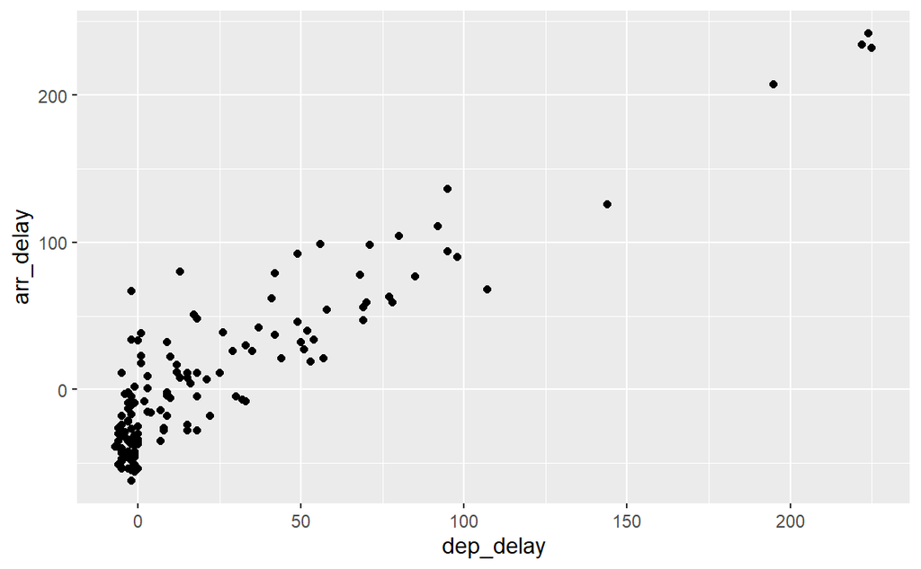

```r
df6 |>
  ggplot(aes(x=dep_delay,y=arr_delay)) +geom_point()
```

> Questions: * Is flight time affected by delayed departure. (Do the airlines try to “catch up”?) * Does the departure delay change across time of day (later in the day has more delays.) * Is flight time pattern affected by time of year * Is departure delay affected by time of year.
- Note to self

## A second visualization:

```r
df1 |>
  filter(dest=="MIA") |>
  count(origin)
```

| origin | n |
| --- | --- |
| EWR | 2633 |
| JFK | 3314 |
| LGA | 5781 |

### Is flight time affected by delayed departure.

I want to examine whether the flight time is impacted by delayed departure.

```r
df7=df1 |>
  filter(dest=="MIA",origin=="LGA") |>
  mutate(flt_delta=arr_delay-dep_delay)
```

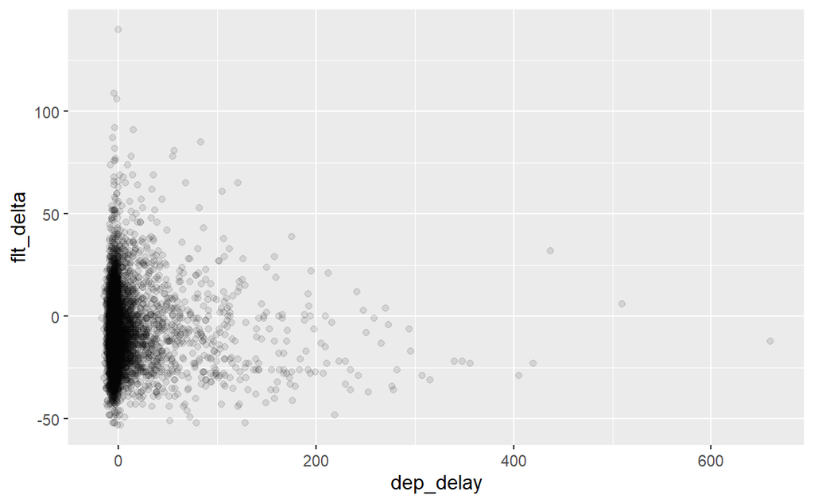

```r
df7 |>
  ggplot(aes(x=dep_delay,y=flt_delta)) +geom_point(alpha=.1)
```

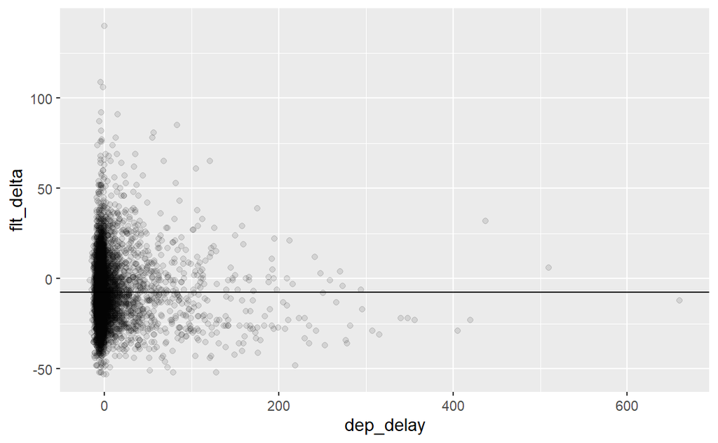

```r
df7 |>
  ggplot(aes(x=dep_delay,y=flt_delta)) +geom_point(alpha=.1)+
  geom_hline(aes(yintercept=mean(flt_delta,na.rm=TRUE)))
```

### Is departure delay affected by time of year

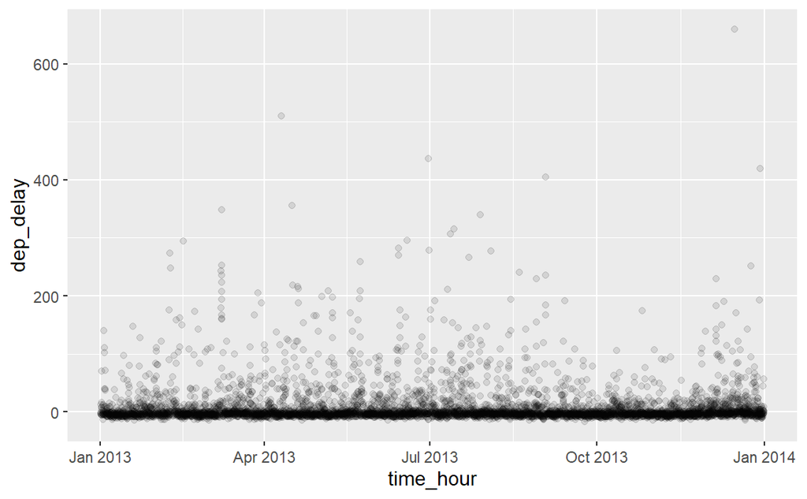

```r
df7 |>
  ggplot(aes(x=time_hour,y=dep_delay)) +geom_point(alpha=.1)
```

```r
NA
```

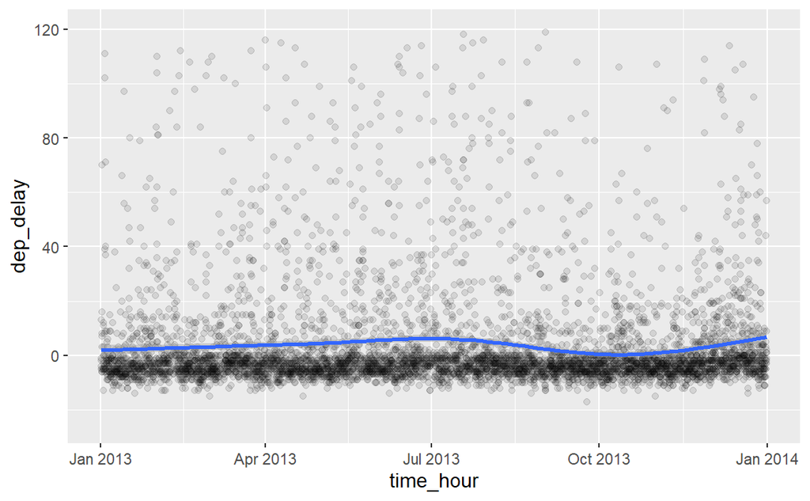

```r
df7 |>
  ggplot(aes(x=time_hour,y=dep_delay)) +
  geom_point(alpha=.1)+
  stat_smooth()+
  ylim(-25,120)
```

```r
NA
```

### Does the departure delay change across time of day?

```r
df7 |>
  ggplot(aes(x=hour+minute/60,y=dep_delay)) +
  geom_point(alpha=.1)+
  stat_smooth()+
  ylim(-25,120)
```

[output not shown]

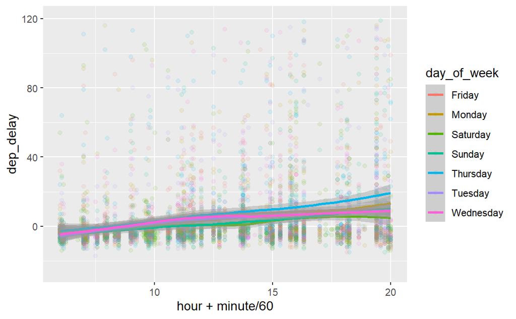

```r
df7 |>
  mutate(day_of_week=weekdays(time_hour)) |>
  ggplot(aes(x=hour+minute/60,y=dep_delay,color=day_of_week)) +
  geom_point(alpha=.1)+
  stat_smooth()+
  ylim(-25,120)
```

```r
NA
```

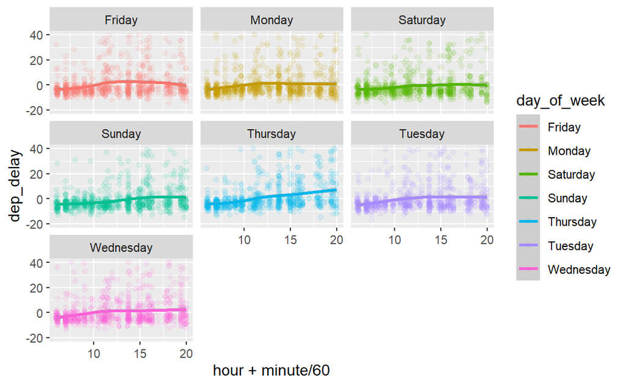

```r
df7 |>
  mutate(day_of_week=weekdays(time_hour)) |>
  ggplot(aes(x=hour+minute/60,y=dep_delay,color=day_of_week)) +
  geom_point(alpha=.1)+
  stat_smooth()+
  ylim(-20,40)+
  facet_wrap(~day_of_week)
```

```r
NA
```